# Model Planning and Model Building

Jennifer Griffiths

November 18, 2019

# The Previous Data

Here is a snipit of the tables that were used in the previous stage of the project:

```r
#This is a snippet of the original table after gather the years into a single column
head(Indicators)
```

```
## # A tibble: 6 x 7
##   dimension  indicator_id indicator_name iso3  country_name Years HDI_value
##   <fct>      <fct>        <fct>          <fct> <fct>        <chr>     <dbl>
## 1 Composite~ 137506       Human Develop~ ALB   Albania      1990      0.645
## 2 Composite~ 137506       Human Develop~ DZA   Algeria      1990      0.577
## 3 Composite~ 137506       Human Develop~ ARG   Argentina    1990      0.704
## 4 Composite~ 137506       Human Develop~ ARM   Armenia      1990      0.631
## 5 Composite~ 137506       Human Develop~ AUS   Australia    1990      0.866
## 6 Composite~ 137506       Human Develop~ AUT   Austria      1990      0.795
```

```r
#Each of the 14 dimensions was subset into its own table (tibble)
unique(Indicators$dimension)
```

```
##  [1] Composite indices                  Demography
##  [3] Education                          Environmental sustainability
##  [5] Gender                             Health
##  [7] Income/composition of resources    Mobility and communication
##  [9] Socio-economic sustainability      Trade and financial flows
## [11] Work, employment and vulnerability Poverty
## [13] Human Security                     Inequality
## 14 Levels: Composite indices Demography ... Work, employment and vulnerability
```

The dimensions are the categories of data that may indicate a countries quality human development. The dimensions have sub-categories called ‘indicators’ (e.g. Dimension: Education, Indicator: Literacy Rate ) The indicator values, across all dimentions are calculated by the United Nations to give a single Human Develoment Index score. For 2019 the top ranked country is Norway, with the United States coming in at number 12.

```r
#The structure of the tibble for the dimension: Education
head(Education)
```

```
## # A tibble: 6 x 7
##   dimension indicator_id indicator_name  iso3  country_name Years HDI_value
##   <fct>     <fct>        <fct>           <fct> <fct>        <chr>     <dbl>
## 1 Education 103706       Education index AFG   Afghanistan  1990      0.122
## 2 Education 103706       Education index ALB   Albania      1990      0.584
## 3 Education 103706       Education index DZA   Algeria      1990      0.385
## 4 Education 103706       Education index ARG   Argentina    1990      0.628
## 5 Education 103706       Education index ARM   Armenia      1990      0.634
## 6 Education 103706       Education index AUS   Australia    1990      0.873
```

```r
#The structure of the tibble for the dimension: Poverty
head(Poverty)
```

```
## # A tibble: 6 x 7
##   dimension indicator_id indicator_name  iso3  country_name Years HDI_value
##   <fct>     <fct>        <fct>           <fct> <fct>        <chr>     <dbl>
## 1 Poverty   153706       Working poor a~ AFG   Afghanistan  1991       98.9
## 2 Poverty   153706       Working poor a~ ALB   Albania      1991        7.8
## 3 Poverty   153706       Working poor a~ DZA   Algeria      1991       27.6
## 4 Poverty   153706       Working poor a~ AGO   Angola       1991       48
## 5 Poverty   153706       Working poor a~ ARG   Argentina    1991        2.6
## 6 Poverty   153706       Working poor a~ ARM   Armenia      1991       27.6
```

# Additional Dataset

## Retrieved from the Food Security Portal API

Which delivers the data in the form of either HTML or CSV. I opted for the CSV verion as I am more comfortable with CSV structure:

```r
AgGDP <- fread('http://www.foodsecurityportal.org/api/countries/agriculture-value-ad.csv')
names(AgGDP)
```

```
##  [1] "V1"  "V2"  "V3"  "V4"  "V5"  "V6"  "V7"  "V8"  "V9"  "V10" "V11"
## [12] "V12" "V13" "V14" "V15" "V16" "V17" "V18" "V19" "V20" "V21" "V22"
## [23] "V23" "V24" "V25" "V26" "V27" "V28" "V29" "V30" "V31" "V32" "V33"
## [34] "V34" "V35" "V36" "V37" "V38" "V39" "V40" "V41" "V42" "V43" "V44"
## [45] "V45" "V46" "V47" "V48" "V49" "V50" "V51" "V52" "V53" "V54" "V55"
## [56] "V56" "V57" "V58"
```

Looking at the structure of the table, the first row should be the column names, lets make that happen.

```r
#grab the first row with the column names
names(AgGDP) <- as.matrix(AgGDP[1, ])
#remove the first row from the table
AgGDP <- AgGDP[-1, ]
#apply the names to the columns
AgGDP[] <- lapply(AgGDP, function(x) type.convert(as.character(x)))
head(AgGDP)
```

```
##                Country 1960 1961 1962 1963 1964     1965     1966     1967
## 1:         Afghanistan   NA   NA   NA   NA   NA       NA       NA       NA
## 2:             Albania   NA   NA   NA   NA   NA       NA       NA       NA
## 3:             Algeria   NA   NA   NA   NA   NA 12.87621 9.137256 10.33067
## 4:             Andorra   NA   NA   NA   NA   NA       NA       NA       NA
## 5:              Angola   NA   NA   NA   NA   NA       NA       NA       NA
## 6: Antigua and Barbuda   NA   NA   NA   NA   NA       NA       NA       NA
##        1968     1969     1970     1971     1972    1973     1974     1975
## 1:       NA       NA       NA       NA       NA      NA       NA       NA
## 2:       NA       NA       NA       NA       NA      NA       NA       NA
## 3: 10.85337 9.030165 9.205466 9.569175 8.420846 7.03976 7.366629 10.41841
## 4:       NA       NA       NA       NA       NA      NA       NA       NA
## 5:       NA       NA       NA       NA       NA      NA       NA       NA
## 6:       NA       NA       NA       NA       NA      NA       NA       NA
##        1976     1977     1978     1979      1980      1981      1982
```

[output cut: 48 more lines]

## Agriculture, Value Added (% GDP)

This dataset documents a counties annual agricultural value added to thier GDP for 1960 - 2016. The agricultural value is the net output of the Agricultural sector which includes forestry, hunting and fishing, and cultivation of crops and livestock production.

## Tidy up

Lets gather all these years into a single column and remove the NA values while we’re here.

```r
AgGDP <-gather(AgGDP, key = Years, "Percent_GDP", 2:58, na.rm = TRUE)
head(AgGDP)
```

```
##         Country Years Percent_GDP
## 15   Bangladesh  1960    57.47431
## 20        Benin  1960    46.15772
## 25     Botswana  1960    43.36449
## 26       Brazil  1960    20.59281
## 29 Burkina Faso  1960    39.81253
## 37         Chad  1960    40.92694
```

## Plot The Data

Lets explore what insights we may gain from the Agricultural GDP data

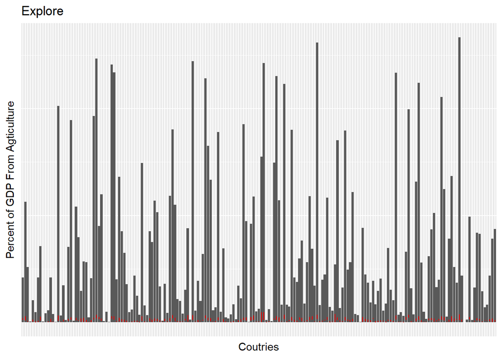

```r
plot <- ggplot(AgGDP, aes(Country, Percent_GDP) ) + geom_col() + geom_path(colour = "red", na.rm = TRUE)
# Rename the x, Y axis to make graph communnicate more clearly
plot + ggtitle("Explore") + theme(axis.text.x = element_blank(), axis.text.y = element_blank(), axis.ticks = element_blank()) + xlab("Coutries") + ylab("Percent of GDP From Agticulture")
```

### Interpretation

From this plot it’s evident that there is quite a spread among countries in their agricultural contributions to GDP. The goal here is to find varibles that can predict a countries percentage of GDP coming from agriculture.

## Lets set up our model

```r
##FOR df TABLE
set.seed(789)

# pass in y value (to be predicted)
sample_selection <- createDataPartition(df$percent_gdp, p = 0.75, list = FALSE)

train <- df[sample_selection, ]
test <- df[-sample_selection, ]
```

## BUILD MODEL FOR ALL VARIABLES::

```r
train_model <- lm(percent_gdp ~
                  dimension
                  + indicator_id
                  + iso3
                  + years
                  + hdi_value
                    , data = train)
summary(train_model)
```

```
##
## Call:
## lm(formula = percent_gdp ~ dimension + indicator_id + iso3 +
##     years + hdi_value, data = train)
##
## Residuals:
##     Min      1Q  Median      3Q     Max
## -23.991  -1.580   0.014   1.375  43.682
##
## Coefficients: (13 not defined because of singularities)
##                                               Estimate Std. Error  t value
## (Intercept)                                  3.251e+01  3.749e-01   86.731
## dimensionDemography                          2.328e-01  3.550e-01    0.656
## dimensionEducation                           1.670e-01  3.659e-01    0.456
## dimensionEnvironmental sustainability        1.802e-01  3.591e-01    0.502
## dimensionGender                              2.058e-01  3.679e-01    0.559
## dimensionHealth                              1.728e-01  3.579e-01    0.483
## dimensionHuman Security                      2.347e-01  3.882e-01    0.605
## dimensionIncome/composition of resources     2.112e-01  3.594e-01    0.588
## dimensionInequality                          1.058e-01  3.773e-01    0.280
## dimensionMobility and communication          1.449e-02  3.680e-01    0.039
## dimensionPoverty                            -1.365e-01  5.682e-01   -0.240
## dimensionSocio-economic sustainability       2.138e-01  3.641e-01    0.587
## dimensionTrade and financial flows           3.174e-01  3.551e-01    0.894
## dimensionWork, employment and vulnerability  1.756e-01  3.599e-01    0.488
## indicator_id23906                            6.981e-02  1.341e-01    0.521
## indicator_id24006                            8.851e-02  1.338e-01    0.661
## indicator_id24106                            7.218e-02  1.332e-01    0.542
## indicator_id24206                            2.401e-02  1.333e-01    0.180
## indicator_id27706                            3.325e-03  1.433e-01    0.023
## indicator_id31706                           -7.748e-02  1.404e-01   -0.552
## indicator_id36806                           -5.661e-02  1.567e-01   -0.361
## indicator_id38406                            2.729e-01  6.296e-01    0.433
## indicator_id38506                           -1.013e-01  6.442e-01   -0.157
## indicator_id38606                           -4.753e-01  6.366e-01   -0.747
## indicator_id43006                            1.537e-02  1.267e-01    0.121
## indicator_id43606                            2.598e-01  1.439e-01    1.806
## indicator_id44206                           -4.961e-02  9.428e-02   -0.526
## indicator_id45106                            3.647e-02  9.411e-02    0.388
## indicator_id45806                           -1.710e-01  1.953e-01   -0.876
```

[output cut: 657 more lines]

```
## years2009                                    < 2e-16 ***
## years2010                                    < 2e-16 ***
## years2011                                    < 2e-16 ***
## years2012                                    < 2e-16 ***
## years2013                                    < 2e-16 ***
## years2014                                    < 2e-16 ***
## years2015                                    < 2e-16 ***
## years2016                                    < 2e-16 ***
## hdi_value                                   0.377551
## ---
## Signif. codes:  0 '***' 0.001 '**' 0.01 '*' 0.05 '.' 0.1 ' ' 1
##
## Residual standard error: 3.667 on 193065 degrees of freedom
## Multiple R-squared:  0.9272, Adjusted R-squared:  0.9271
## F-statistic:  7390 on 333 and 193065 DF,  p-value: < 2.2e-16
```

This summary tells us that the iso3 (officially assigned country codes) is a significant indicatior, which is not meaningful - as the percent of a countries GPD that is Agricultural is directly linked to the country.

Lets remove some of the variables to clean up this model. “Years” and “iso” are irrelevant relationships because the country and the year are information that directly link the annual agricultual GDP to a country. Lets also remove dimentions as that vRble has a consistant high P-value across all levels - meaning none of the dimension categories are statistically significant. ###Revised Model

```r
train_model <- lm(percent_gdp ~
                   indicator_id
                  + hdi_value
                    , data = train)
summary(train_model)
```

```
##
## Call:
## lm(formula = percent_gdp ~ indicator_id + hdi_value, data = train)
##
## Residuals:
##     Min      1Q  Median      3Q     Max
## -22.985 -10.304  -4.489   6.800 140.443
##
## Coefficients:
##                      Estimate Std. Error t value Pr(>|t|)
## (Intercept)         1.302e+01  4.092e-01  31.822  < 2e-16 ***
## indicator_id23906   1.377e+00  4.890e-01   2.816 0.004856 **
## indicator_id24006   1.197e+00  4.879e-01   2.455 0.014108 *
## indicator_id24106   1.682e+00  4.856e-01   3.463 0.000534 ***
## indicator_id24206   1.502e+00  4.862e-01   3.089 0.002011 **
## indicator_id27706   1.427e+00  5.837e-01   2.444 0.014511 *
## indicator_id31706   6.776e-01  4.955e-01   1.368 0.171463
## indicator_id36806   1.051e+00  5.568e-01   1.887 0.059168 .
## indicator_id38406   4.715e+00  1.666e+00   2.830 0.004660 **
## indicator_id38506   3.772e+00  1.739e+00   2.169 0.030117 *
## indicator_id38606   4.673e+00  1.702e+00   2.746 0.006033 **
## indicator_id43006   8.391e-01  5.236e-01   1.602 0.109073
## indicator_id43606   4.496e-01  5.080e-01   0.885 0.376127
## indicator_id44206   2.193e+00  4.754e-01   4.613 3.97e-06 ***
## indicator_id45106   2.480e+00  4.749e-01   5.222 1.77e-07 ***
## indicator_id45806   2.550e+00  7.131e-01   3.576 0.000349 ***
## indicator_id46006   3.803e-01  5.081e-01   0.749 0.454120
## indicator_id46106   6.942e-01  6.167e-01   1.126 0.260294
## indicator_id46206   5.810e-01  5.621e-01   1.034 0.301310
## indicator_id47906   2.775e+00  6.667e-01   4.163 3.15e-05 ***
## indicator_id48706   7.847e-01  5.250e-01   1.495 0.134991
## indicator_id48806   1.068e+00  5.257e-01   2.031 0.042248 *
## indicator_id49006   2.189e+00  6.328e-01   3.460 0.000541 ***
## indicator_id52306  -4.878e+00  7.303e-01  -6.679 2.41e-11 ***
## indicator_id52606   1.532e+00  4.857e-01   3.154 0.001609 **
## indicator_id53506   2.322e+00  4.778e-01   4.860 1.18e-06 ***
## indicator_id57206   2.341e+00  4.758e-01   4.921 8.64e-07 ***
## indicator_id57506   2.338e+00  4.754e-01   4.917 8.78e-07 ***
## indicator_id57806   2.513e+00  4.775e-01   5.262 1.42e-07 ***
## indicator_id57906   2.656e+00  4.784e-01   5.553 2.82e-08 ***
```

[output cut: 97 more lines]

```
## indicator_id179706  6.387e-01  6.462e-01   0.988 0.322912
## indicator_id181206 -1.533e+00  5.936e-01  -2.583 0.009783 **
## indicator_id181606  6.175e-01  5.177e-01   1.193 0.232984
## indicator_id181706  4.994e-01  5.633e-01   0.887 0.375288
## indicator_id181806  7.785e-01  5.107e-01   1.524 0.127456
## indicator_id182106  7.538e+00  8.705e-01   8.659  < 2e-16 ***
## indicator_id182206  6.291e-01  5.063e-01   1.243 0.214045
## indicator_id183406  9.776e+00  1.693e+00   5.776 7.66e-09 ***
## hdi_value          -4.005e-04  8.195e-06 -48.877  < 2e-16 ***
## ---
## Signif. codes:  0 '***' 0.001 '**' 0.01 '*' 0.05 '.' 0.1 ' ' 1
##
## Residual standard error: 13.42 on 193263 degrees of freedom
## Multiple R-squared:  0.02478,    Adjusted R-squared:  0.0241
## F-statistic: 36.38 on 135 and 193263 DF,  p-value: < 2.2e-16
```

With this revised model we can see more of the indicators that would be considered statistically significant (low P-Values marked with astericks). There are a total of 74 ’indicator id’s" and the HDI value which gives the grand total of 75 statistically significant markers for a countries annual percentage of GDP comming from Agriculture.

Lets explore some of these indicators with the lowest P values.

# Significant indicator (indicator id : 69206, P-Value : 5.23e-06)

```r
Significant_indicator01 <- subset(Indicators, indicator_id == "69206")
Significant_indicator01[1,]
```

```
## # A tibble: 1 x 7
##   dimension indicator_id indicator_name  iso3  country_name Years HDI_value
##   <fct>     <fct>        <fct>           <fct> <fct>        <chr>     <dbl>
## 1 Health    69206        Life expectanc~ AFG   Afghanistan  1990       49.9
```

### Percentage of GDP from Agriculture and Life expectancy at birth (years)

To clarify, the X value will be the HDI score, as that is the value for the indicator id. Here the HDI Score is the average life expectancy in years for a country.

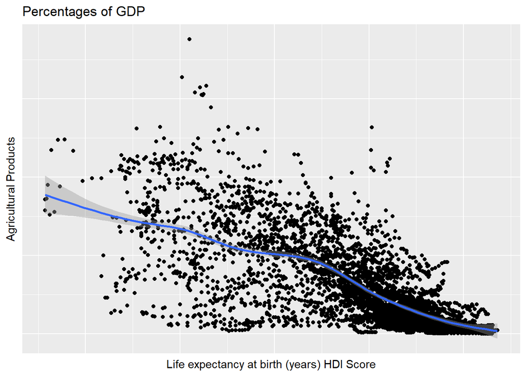

```r
AgToLifeExpectancy <- subset(df, indicator_id == "69206" )
ggplot(AgToLifeExpectancy, aes(x = hdi_value, y = percent_gdp)) + geom_point() + geom_smooth() + ggtitle("Percentages of GDP") + theme(axis.text.x = element_blank(), axis.text.y = element_blank(), axis.ticks = element_blank()) + xlab("Life expectancy at birth (years) HDI Score") + ylab("Agricultural Products")
```

### Assessment of Graph

This is not what I expected to see. This graph indicates that as the average life expectancy increases, the percentage of GDP that is Agricultural decreases. Potentially this is due to wealthy countries produce a greater diversity of products that contribute to their overall GDP, whereas developing countries primarily produce agricultural products, raw materials, and labor. More GDP data would be needed to corroborate this assumption.

# Significant indicator (indicator id : 58006, P-Value : < 2e-16)

```r
Sig_indicator02 <- subset(Indicators, indicator_id == "58006")
Sig_indicator02[2,]
```

```
## # A tibble: 1 x 7
##   dimension indicator_id indicator_name  iso3  country_name Years HDI_value
##   <fct>     <fct>        <fct>           <fct> <fct>        <chr>     <dbl>
## 1 Health    58006        HIV prevalence~ ALB   Albania      1990        0.1
```

### Percentage of GDP from Agriculture and HIV prevalence, adult (% ages 15-49)

Our X value here is the HDI value which is the percentage value for the indicator “HIV prevalence, adult (% ages 15-49)”.

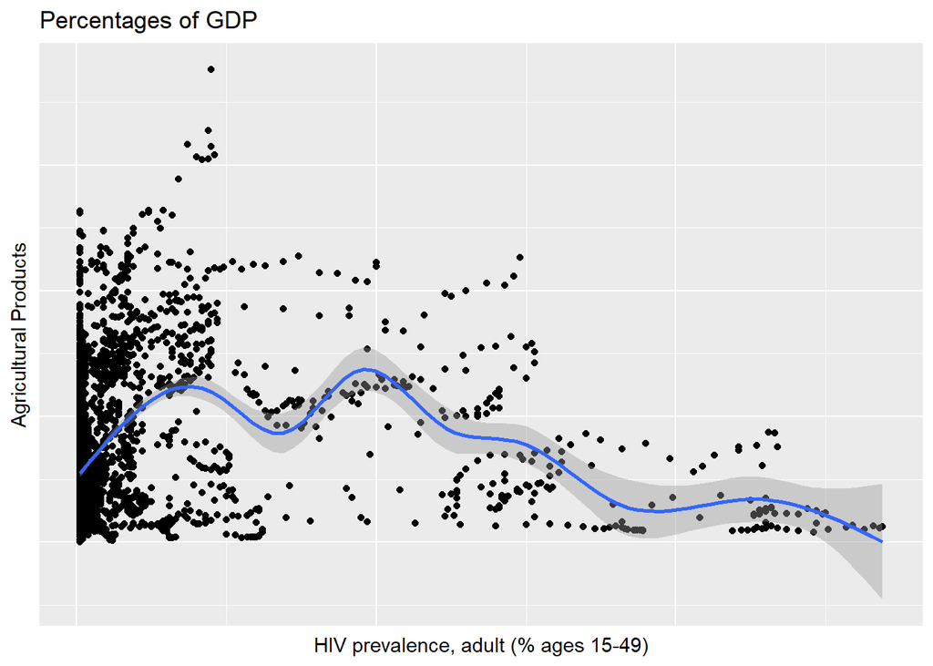

```r
AgToLHIV <- subset(df, indicator_id == "58006" )
ggplot(AgToLHIV, aes(x = hdi_value, y = percent_gdp)) + geom_point() + geom_smooth() + ggtitle("Percentages of GDP") + theme(axis.text.x = element_blank(), axis.text.y = element_blank(), axis.ticks = element_blank()) + xlab("HIV prevalence, adult (% ages 15-49)") + ylab("Agricultural Products")
```

### Assessment of Graph

Thats a funky funky shape. This shape may be skewed by rises and falls of rates of HIV over the years, as each dot represents each country for each year between 1990 and 2017. The graph doesn’t appear to communicate anything terribly interesting. Potentially it indicates that the highest HIV prevelence occurred in a country with a lower annual Agricultural percentage of the GDP, but it is to noisy to make any conclusions.

# Significant indicator (indicator id : 123606, P-Value : < 2e-16)

```r
Sig_indicator03 <- subset(Indicators, indicator_id == "123606")
Sig_indicator03[2,]
```

```
## # A tibble: 1 x 7
##   dimension indicator_id indicator_name  iso3  country_name Years HDI_value
##   <fct>     <fct>        <fct>           <fct> <fct>        <chr>     <dbl>
## 1 Gender    123606       Estimated gros~ CHL   Chile        1990      12677
```

### Percentage of GDP from Agriculture and Estimated gross national income per capita, male (2011 PPP $)

Our X value here is the HDI value which is the dollar value for the indicator “Estimated gross national income per capita, male (2011 PPP $)”.

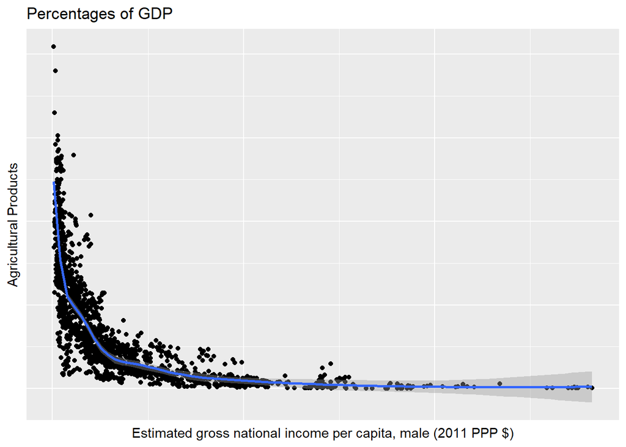

```r
AgToLMaleIncome <- subset(df, indicator_id == "123606" )
ggplot(AgToLMaleIncome, aes(x = hdi_value, y = percent_gdp)) + geom_point() + geom_smooth() + ggtitle("Percentages of GDP") + theme(axis.text.x = element_blank(), axis.text.y = element_blank(), axis.ticks = element_blank()) + xlab("Estimated gross national income per capita, male (2011 PPP $)") + ylab("Agricultural Products")
```

### Assessment of Graph

This looks very close to: [ y = 1/x ]. As the percentage of GDP that comes from Agriculture decreases, the per capita male income increases. This seems to have a direct relationship. My assumption would be that a country that has a significant portion of it’s GDP comming from Agriculture, has a vast majority of its population working the land. Unfortunately, across the globe, that peope that labor to produce our food, do not make much money.

# Significant indicator (indicator id : 69706, P-Value : 2.47e-05)

```r
Sig_indicator04 <- subset(Indicators, indicator_id == "69706")
Sig_indicator04[2,]
```

```
## # A tibble: 1 x 7
##   dimension indicator_id indicator_name  iso3  country_name Years HDI_value
##   <fct>     <fct>        <fct>           <fct> <fct>        <chr>     <dbl>
## 1 Education 69706        Expected years~ ALB   Albania      1990       11.6
```

### Percentage of GDP from Agriculture and Expected years of schooling (years)

Our X value here is the HDI value which is the years for the indicator “Expected years of schooling (years)”.

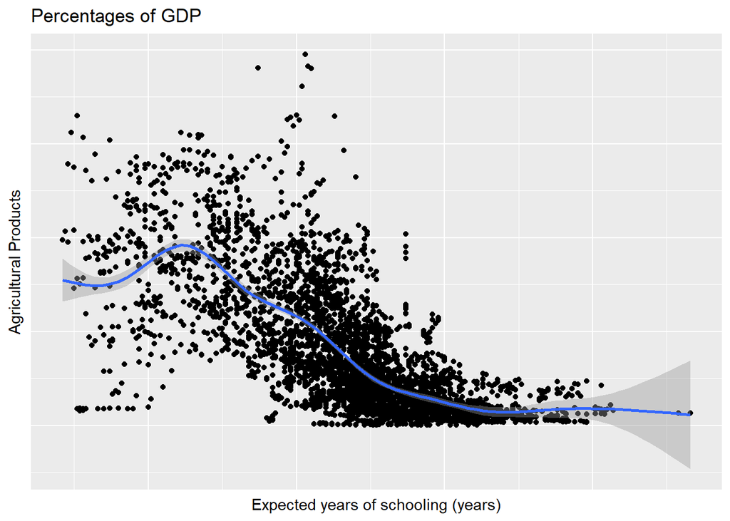

```r
AgToEducation <- subset(df, indicator_id == "69706" )
ggplot(AgToEducation, aes(x = hdi_value, y = percent_gdp)) + geom_point() + geom_smooth() + ggtitle("Percentages of GDP") + theme(axis.text.x = element_blank(), axis.text.y = element_blank(), axis.ticks = element_blank()) + xlab("Expected years of schooling (years)") + ylab("Agricultural Products")
```

### Assessment of Graph

It’s a bit noisy at the head, but tightens up at the tail. This graph lines up with the other graphs in terms of the negative relationships. Here we can see that as expected years of schooling increases, the agricultural contribution to overall GDP drops.

> I could spent all day graphing these relationships, but lets stop here and give a preliminary evaluation of this model

### TABLES USED CREATING THE MODEL

```r
head(AgGDP)
```

```
##    country_name Years Percent_GDP
## 15   Bangladesh  1960    57.47431
## 20        Benin  1960    46.15772
## 25     Botswana  1960    43.36449
## 26       Brazil  1960    20.59281
## 29 Burkina Faso  1960    39.81253
## 37         Chad  1960    40.92694
```

```r
head(df)
```

```
##      country_name years percent_gdp         dimension indicator_id
## 2228      Albania  1990    35.90079 Composite indices       137506
## 2229      Albania  1990    35.90079        Demography        47906
## 2230      Albania  1990    35.90079        Demography       122006
## 2231      Albania  1990    35.90079        Demography        63106
## 2232      Albania  1990    35.90079        Demography       132706
## 2233      Albania  1990    35.90079        Demography       132806
##                                                           indicator_name
## 2228                                       Human Development Index (HDI)
## 2229                                                  Median age (years)
## 2230 Old-age (65 and older) dependency ratio (per 100 people ages 15-64)
## 2231                                    Population ages 15–64 (millions)
## 2232                             Population ages 65 and older (millions)
## 2233                                   Population under age 5 (millions)
##      iso3 hdi_value
## 2228  ALB     0.645
## 2229  ALB    24.100
## 2230  ALB     8.900
## 2231  ALB     2.000
## 2232  ALB     0.200
## 2233  ALB     0.400
```